# Diagnóstico do dado bruto: Viagens IFs Nordeste

Introdução à Ciência de Dados - Atividade prática da Etapa 1

Autor

Franciele Alves da Silva - 20231SI0012, Kaillane Corrêa Martins - 20211SI0023, Samuel Chaves de Sá - 20231SI0011

Data de Publicação

7 de novembro de 2026

```python
import json
import pandas as pd
from pathlib import Path
from IPython.display import display # <-- ADICIONADO PARA CORRIGIR ERRO NO RENDER

# 1. Define a pasta raiz (base) onde estão todas as subpastas
pasta_base = Path(r"data\raw\portal_transparencia")

# 2. O rglob vasculha todas as pastas e subpastas procurando arquivos .json
arquivos_json = list(pasta_base.rglob("*.json"))
print(f"Encontrados {len(arquivos_json)} arquivos JSON. Iniciando a leitura...")

todas_as_viagens = []

# 3. Abre cada arquivo encontrado e junta os dados em uma lista única
for arquivo in arquivos_json:
    try:
        with open(arquivo, 'r', encoding='utf-8') as f:
            dados_brutos = json.load(f)

            # Verifica se a chave 'dados' existe e tem informações
            if 'dados' in dados_brutos and isinstance(dados_brutos['dados'], list):
                # Opcional: Você pode querer saber de qual arquivo o dado veio
                # for viagem in dados_brutos['dados']:
                #     viagem['arquivo_origem'] = arquivo.name

                todas_as_viagens.extend(dados_brutos['dados'])
    except Exception as e:
        print(f"Erro ao ler o arquivo {arquivo}: {e}")

# 4. Transforma essa superlista achatada em um único DataFrame
df_viagens = pd.json_normalize(todas_as_viagens)

# 5. Limpa e converte as colunas financeiras
colunas_financeiras = ['valorTotalDiarias', 'valorTotalPassagem', 'valorTotalViagem', 'valorTotalDevolucao']

for col in colunas_financeiras:
    if col in df_viagens.columns:
        if df_viagens[col].dtype == 'object':
            df_viagens[col] = df_viagens[col].astype(str).str.replace('.', '', regex=False).str.replace(',', '.', regex=False).astype(float)

# 6. Mostra o resultado final consolidado
print(f"Leitura concluída com sucesso!")
print(f"Total de viagens consolidadas: {len(df_viagens)}")
display(df_viagens.head(3))
```

```
Encontrados 264 arquivos JSON. Iniciando a leitura...
Leitura concluída com sucesso!
Total de viagens consolidadas: 47359
```

|  | id | situacao | tipoViagem | dataInicioAfastamento | dataFimAfastamento | valorTotalRestituicao | valorTotalTaxaAgenciamento | valorMulta | valorTotalDiarias | valorTotalPassagem | ... | unidadeGestoraResponsavel.codigo | unidadeGestoraResponsavel.nome | unidadeGestoraResponsavel.descricaoPoder | unidadeGestoraResponsavel.orgaoVinculado.codigoSIAFI | unidadeGestoraResponsavel.orgaoVinculado.cnpj | unidadeGestoraResponsavel.orgaoVinculado.sigla | unidadeGestoraResponsavel.orgaoVinculado.nome | unidadeGestoraResponsavel.orgaoMaximo.codigo | unidadeGestoraResponsavel.orgaoMaximo.sigla | unidadeGestoraResponsavel.orgaoMaximo.nome |
| --- | --- | --- | --- | --- | --- | --- | --- | --- | --- | --- | --- | --- | --- | --- | --- | --- | --- | --- | --- | --- | --- |
| 0 | 497870947 | Realizada | Nacional | 2025-01-21 | 2025-01-22 | 0.0 | 0.0 | 0.0 | 385.84 | 0.0 | ... | 151609 | CAMPUS CAICO - IFRN | EXECUTIVO | 26435 | 10877412000168 | IFRN | Instituto Federal de Educação, Ciência e Tecno... | 26000 | MEC | Ministério da Educação |
| 1 | 497861767 | Realizada | Nacional | 2025-01-22 | 2025-01-24 | 0.0 | 0.0 | 0.0 | 701.15 | 0.0 | ... | 151606 | CAMPUS CURRAIS NOVOS - IFRN | EXECUTIVO | 26435 | 10877412000168 | IFRN | Instituto Federal de Educação, Ciência e Tecno... | 26000 | MEC | Ministério da Educação |
| 2 | 497880045 | Realizada | Nacional | 2025-01-30 | 2025-01-31 | 0.0 | 0.0 | 0.0 | 457.96 | 0.0 | ... | 151609 | CAMPUS CAICO - IFRN | EXECUTIVO | 26435 | 10877412000168 | IFRN | Instituto Federal de Educação, Ciência e Tecno... | 26000 | MEC | Ministério da Educação |

3 rows × 51 columns

## 1. Perfil do arquivo bruto

```
Arquivo transformado salvo em: data\processed\viagens_transformadas.csv
```

|  | column_name | column_type | count | approx_unique | null_percentage | min | max |
| --- | --- | --- | --- | --- | --- | --- | --- |
| 0 | id | BIGINT | 47359 | 47090 | 0.00 | 496951310 | 499262178 |
| 1 | situacao | VARCHAR | 47359 | 2 | 0.00 | Não realizada | Realizada |
| 2 | tipoViagem | VARCHAR | 47359 | 2 | 0.00 | Internacional | Nacional |
| 3 | dataInicioAfastamento | DATE | 47359 | 663 | 0.00 | 2024-01-02 | 2025-12-29 |
| 4 | dataFimAfastamento | DATE | 47359 | 630 | 0.00 | 2024-01-03 | 2025-12-31 |
| 5 | valorTotalRestituicao | DOUBLE | 47359 | 1419 | 0.00 | 0.0 | 2109.86 |
| 6 | valorTotalTaxaAgenciamento | DOUBLE | 47359 | 1 | 0.00 | 0.0 | 0.0 |
| 7 | valorMulta | DOUBLE | 47359 | 1 | 0.00 | 0.0 | 0.0 |
| 8 | valorTotalDiarias | DOUBLE | 47359 | 7028 | 0.00 | 0.0 | 23523.62 |
| 9 | valorTotalPassagem | DOUBLE | 47359 | 3782 | 0.00 | 0.0 | 17230.25 |
| 10 | valorTotalViagem | DOUBLE | 47359 | 10822 | 0.00 | 0.0 | 31624.07 |
| 11 | valorTotalDevolucao | DOUBLE | 47359 | 230 | 0.00 | 0.0 | 3167.75 |
| 12 | viagem.motivo | VARCHAR | 47359 | 36363 | 0.00 | "123ª Reunião Ordinária do Coldir." processo S... | árvores e outras demandas do Campus Palmeira d... |
| 13 | viagem.pcdp | VARCHAR | 47359 | 51705 | 0.00 | 0000000000019192663 | 0000000000021933849 |
| 14 | viagem.ano | BIGINT | 47359 | 2 | 0.00 | 2024 | 2025 |
| 15 | viagem.numPcdp | VARCHAR | 47359 | 8948 | 0.00 | 000001/24 | Informações protegidas por sigilo |
| 16 | viagem.justificativaUrgente | VARCHAR | 47359 | 24569 | 0.00 | "1 - Motivo da não observância quanto ao prazo... | Única data disponível pelas empresas para real... |
| 17 | viagem.urgenciaViagem | VARCHAR | 47359 | 3 | 0.00 | Não | Sim |
| 18 | beneficiario.cpfFormatado | VARCHAR | 47359 | 12779 | 0.01 | ***.000.000-** | ***.999.971-** |
| 19 | beneficiario.nis | VARCHAR | 47359 | 0 | 100.00 | NaN | NaN |
| 20 | beneficiario.nome | VARCHAR | 47359 | 10537 | 0.00 | AARAO CARLOS LUZ MACAMBIRA | ZULEICA TAVARES VASCONCELOS OLIVEIRA |
| 21 | cargo.codigoSIAPE | VARCHAR | 47359 | 131 | 0.01 | 000000000000000000000000000000 | 000000000000000000000000707003 |
| 22 | cargo.descricao | VARCHAR | 47359 | 135 | 6.40 | ADMINISTRADOR | ZOOTECNISTA |
| 23 | funcao.codigoSIAPE | VARCHAR | 47359 | 32 | 0.00 | -1 | Suboficial |
| 24 | funcao.descricao | VARCHAR | 47359 | 32 | 0.00 | CCX-0102 | Suboficial |
| 25 | orgao.nome | VARCHAR | 47359 | 11 | 0.00 | Instituto Federal de Educação, Ciência e Tecno... | Instituto Federal de Educação, Ciência e Tecno... |
| 26 | orgao.codigoSIAFI | BIGINT | 47359 | 10 | 0.00 | 26402 | 26435 |
| 27 | orgao.cnpj | BIGINT | 47359 | 11 | 0.00 | 10724903000179 | 10877412000168 |
| 28 | orgao.sigla | VARCHAR | 47359 | 11 | 0.00 | IFAL | IFSERTAO |
| 29 | orgao.descricaoPoder | VARCHAR | 47359 | 1 | 0.00 | EXECUTIVO | EXECUTIVO |
| 30 | orgao.orgaoMaximo.codigo | BIGINT | 47359 | 1 | 0.00 | 26000 | 26000 |
| 31 | orgao.orgaoMaximo.sigla | VARCHAR | 47359 | 1 | 0.00 | MEC | MEC |
| 32 | orgao.orgaoMaximo.nome | VARCHAR | 47359 | 1 | 0.00 | Ministério da Educação | Ministério da Educação |
| 33 | orgaoPagamento.nome | VARCHAR | 47359 | 11 | 0.00 | Instituto Federal de Educação, Ciência e Tecno... | Instituto Federal de Educação, Ciência e Tecno... |
| 34 | orgaoPagamento.codigoSIAFI | BIGINT | 47359 | 10 | 0.00 | 26402 | 26435 |
| 35 | orgaoPagamento.cnpj | BIGINT | 47359 | 11 | 0.00 | 10724903000179 | 10877412000168 |
| 36 | orgaoPagamento.sigla | VARCHAR | 47359 | 11 | 0.00 | IFAL | IFSERTAO |
| 37 | orgaoPagamento.descricaoPoder | VARCHAR | 47359 | 1 | 0.00 | EXECUTIVO | EXECUTIVO |
| 38 | orgaoPagamento.orgaoMaximo.codigo | BIGINT | 47359 | 1 | 0.00 | 26000 | 26000 |
| 39 | orgaoPagamento.orgaoMaximo.sigla | VARCHAR | 47359 | 1 | 0.00 | MEC | MEC |
| 40 | orgaoPagamento.orgaoMaximo.nome | VARCHAR | 47359 | 1 | 0.00 | Ministério da Educação | Ministério da Educação |
| 41 | unidadeGestoraResponsavel.codigo | BIGINT | 47359 | 275 | 0.00 | -11 | 158741 |
| 42 | unidadeGestoraResponsavel.nome | VARCHAR | 47359 | 284 | 0.00 | CAMPUS ACARAU/IFCE | UGR - TED PARFOR |
| 43 | unidadeGestoraResponsavel.descricaoPoder | VARCHAR | 47359 | 1 | 1.33 | EXECUTIVO | EXECUTIVO |
| 44 | unidadeGestoraResponsavel.orgaoVinculado.codig... | BIGINT | 47359 | 13 | 0.00 | -11 | 26435 |
| 45 | unidadeGestoraResponsavel.orgaoVinculado.cnpj | BIGINT | 47359 | 11 | 1.33 | 10724903000179 | 10877412000168 |
| 46 | unidadeGestoraResponsavel.orgaoVinculado.sigla | VARCHAR | 47359 | 11 | 1.33 | IFAL | IFSERTAO |
| 47 | unidadeGestoraResponsavel.orgaoVinculado.nome | VARCHAR | 47359 | 12 | 1.32 | Instituto Federal de Educação, Ciência e Tecno... | Sigiloso |
| 48 | unidadeGestoraResponsavel.orgaoMaximo.codigo | BIGINT | 47359 | 3 | 0.00 | -11 | 26000 |
| 49 | unidadeGestoraResponsavel.orgaoMaximo.sigla | VARCHAR | 47359 | 3 | 0.00 | -1 | MEC |
| 50 | unidadeGestoraResponsavel.orgaoMaximo.nome | VARCHAR | 47359 | 3 | 0.00 | Ministério da Educação | Sigiloso |

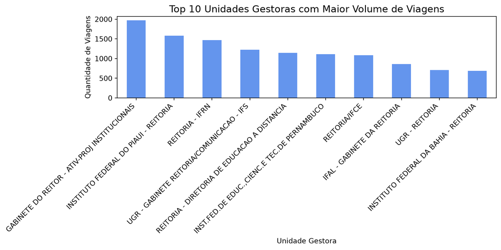

```python
from pathlib import Path
import duckdb
import matplotlib.pyplot as plt

# 1. Define o caminho do arquivo transformado
caminho_saida = Path(r"data\processed\viagens_transformadas.csv")

# 2. Cria a pasta processed (caso não exista)
caminho_saida.parent.mkdir(parents=True, exist_ok=True)

# 3. Salva o DataFrame (exatamente como foi lido e achatado, sem limpar)
df_viagens.to_csv(caminho_saida, index=False, encoding='utf-8')
print(f"Arquivo transformado salvo em: {caminho_saida}\n")

# 4. Gera o Perfil com o DuckDB lendo o arquivo recém-salvo
CSV = str(caminho_saida)
con = duckdb.connect()
perfil = con.sql(f"SUMMARIZE SELECT * FROM '{CSV}'").df()

# 5. Exibe a tabela de perfil com as colunas selecionadas
df_perfil = perfil[["column_name", "column_type", "count", "approx_unique", "null_percentage", "min", "max"]]
display(df_perfil)

plt.figure(figsize=(10, 5))
# <-- CORRIGIDO: Era 'df', agora é 'df_viagens' para o gráfico funcionar
top_campi = df_viagens["unidadeGestoraResponsavel.nome"].value_counts().head(10)
top_campi.plot(kind="bar", color="cornflowerblue")
plt.title("Top 10 Unidades Gestoras com Maior Volume de Viagens", fontsize=14)
plt.xlabel("Unidade Gestora")
plt.ylabel("Quantidade de Viagens")
plt.xticks(rotation=45, ha="right")
plt.tight_layout()
plt.show()
```

O perfil revela que a base de dados possui 47.359 registros. A coluna id (chave primária) apresenta um approx_unique de ~47.090, mas como se trata de uma estimativa estatística do DuckDB, verificaremos a exatidão na próxima etapa. As colunas temporais e financeiras já estão tipadas corretamente como DATE e DOUBLE, apresentando valores mínimos e máximos plausíveis (ex: R$ 31.624 para valorTotalViagem). Sobre os dados ausentes, a coluna beneficiario.nis destaca-se com 100% de nulos, enquanto cargo.descricao e informações da unidadeGestoraResponsavel possuem perdas menores (6.4% e ~1.3%). Por fim, o approx_unique de viagem.numPcdp (~8.948) comprova que o sistema agrupa múltiplos passageiros e trechos sob o mesmo número de processo.

## 2. Duplicatas

```python
import duckdb

# 1. Define o caminho do arquivo e cria a conexão
CSV = r"data\processed\viagens_transformadas.csv"
con = duckdb.connect()

# 2. Carrega os dados para o DataFrame
df = con.sql(f"SELECT * FROM '{CSV}'").df()

# 3. Define a CHAVE que identifica unicamente a viagem
if 'id' in df.columns:
    CHAVE = 'id'
elif 'viagem.pcdp' in df.columns:
    CHAVE = ['viagem.pcdp', 'beneficiario.cpfFormatado']
else:
    CHAVE = df.columns[0] # Fallback do template

# 4. Calcula as duplicatas
dup_linha = int(df.duplicated().sum())
dup_chave = int(df.duplicated(subset=CHAVE).sum())

print(f"linhas: {len(df)}")
print(f"duplicadas por linha inteira: {dup_linha}")
print(f"duplicadas por {CHAVE}: {dup_chave}")
```

```
linhas: 47359
duplicadas por linha inteira: 0
duplicadas por id: 0
```

As contagens de duplicatas por linha inteira e por chave (id) retornaram zero, provando que a diferença vista no approx_unique do perfil era apenas a margem de erro da estimativa do DuckDB. A base de dados foi extraída com sucesso sem nenhuma redundância de paginação ou sobreposição de registros. A função drop_duplicates() foi mantida apenas por segurança, mas não alterou o volume final do dataset.

```python
antes = len(df)
df = df.drop_duplicates().reset_index(drop=True)
print(f"{antes} -> {len(df)} linhas apos remover cópias exatas")

# Substitua o 1000 pelo número real de linhas que você tem agora (ex: 47359)
assert len(df) == 47359, f"A contagem apos dedup mudou. Temos {len(df)} linhas."
```

```
47359 -> 47359 linhas apos remover cópias exatas
```

## 3. Tabela de decisão

```
--- Tabela de Percentual de Ausência ---
```

|  | pct_nulo |
| --- | --- |
| beneficiario.nis | 100.0 |
| cargo.descricao | 6.4 |
| unidadeGestoraResponsavel.descricaoPoder | 1.3 |
| unidadeGestoraResponsavel.orgaoVinculado.cnpj | 1.3 |
| unidadeGestoraResponsavel.orgaoVinculado.sigla | 1.3 |
| unidadeGestoraResponsavel.orgaoVinculado.nome | 1.3 |

```
--- Matriz Visual de Dados Ausentes ---
```

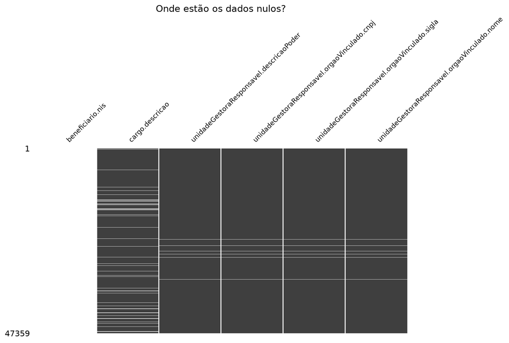

```python
import missingno as msno
import matplotlib.pyplot as plt

# 1. Ponto de partida: quais colunas têm ausência, e quanto.
ausencia = (df.isna().mean() * 100).round(1)
df_ausencia = ausencia[ausencia > 0].sort_values(ascending=False).to_frame("pct_nulo")

print("--- Tabela de Percentual de Ausência ---")
display(df_ausencia)

# 2. Visualização gráfica com Missingno
# Filtramos o DataFrame para mostrar apenas as colunas que têm dados faltando (para o gráfico não ficar gigante e inútil)
colunas_com_nulos = df_ausencia.index.tolist()

if colunas_com_nulos:
    print("\n--- Matriz Visual de Dados Ausentes ---")
    # A matriz (matrix) plota as linhas. Onde houver risco branco, o dado é nulo.
    msno.matrix(df[colunas_com_nulos], figsize=(10, 5), fontsize=10, sparkline=False)
    plt.title("Onde estão os dados nulos?", fontsize=14)
    plt.show()
else:
    print("Nenhuma coluna possui valores nulos.")
```

```python
# Consulta 1: Por que 'cargo.descricao' está ausente?
# Geralmente isso acontece porque a pessoa não é servidora de carreira (ex: é convidado, aluno, ou tem apenas função comissionada).
q_cargo = con.sql(f"""
    SELECT "funcao.descricao",
           count(*) AS registros,
           count(*) FILTER (WHERE "cargo.descricao" IS NULL) AS ausentes,
           round(100.0 * count(*) FILTER (WHERE "cargo.descricao" IS NULL)
                 / count(*), 1) AS pct
    FROM '{CSV}'
    GROUP BY 1
    HAVING registros > 10
    ORDER BY pct DESC
    LIMIT 5
""").df()

print("--- Padrão de Ausência: Cargo ---")
display(q_cargo)

# Consulta 2: Por que as colunas de 'unidadeGestoraResponsavel' sumiram juntas (1.3%)?
# A hipótese é que 1 ou 2 campi específicos estão com o cadastro incompleto no sistema do governo.
q_ugr = con.sql(f"""
    SELECT "unidadeGestoraResponsavel.nome",
           count(*) AS registros,
           count(*) FILTER (WHERE "unidadeGestoraResponsavel.descricaoPoder" IS NULL) AS ausentes,
           round(100.0 * count(*) FILTER (WHERE "unidadeGestoraResponsavel.descricaoPoder" IS NULL)
                 / count(*), 1) AS pct
    FROM '{CSV}'
    GROUP BY 1
    ORDER BY ausentes DESC
    LIMIT 5
""").df()

print("\n--- Padrão de Ausência: Unidade Gestora ---")
display(q_ugr)
```

```
--- Padrão de Ausência: Cargo ---
```

|  | funcao.descricao | registros | ausentes | pct |
| --- | --- | --- | --- | --- |
| 0 | Sem informação | 23220 | 2957 | 12.7 |
| 1 | Cargo Comissionado de Direção | 12839 | 54 | 0.4 |
| 2 | FG-0002 | 3796 | 6 | 0.2 |
| 3 | FG-0001 | 3553 | 2 | 0.1 |
| 4 | FG-0005 | 217 | 0 | 0.0 |

```
--- Padrão de Ausência: Unidade Gestora ---
```

|  | unidadeGestoraResponsavel.nome | registros | ausentes | pct |
| --- | --- | --- | --- | --- |
| 0 | Sem informação | 586 | 586 | 100.0 |
| 1 | Inválido | 39 | 39 | 100.0 |
| 2 | Sigilosa | 3 | 3 | 100.0 |
| 3 | IFPI/PIRIPIRI | 80 | 0 | 0.0 |
| 4 | CAMPUS NATAL CIDADE ALTA - IFRN | 45 | 0 | 0.0 |

[output not shown]

## 4. Tratamento

```python
# --- Tratamento de dados ausentes ---
# Os valores ausentes serão identificados por flags e preenchidos com o texto
# "Não informado". Não será utilizada moda nem outra estimativa estatística.

# 1. Tratamento da coluna 100% ausente (classificação não determinável)
df = df.drop(columns=["beneficiario.nis"])
assert "beneficiario.nis" not in df.columns, "Erro: Coluna NIS não foi excluída."

# 2. Tratamento de cargo.descricao (6.4% ausente - MAR)
# Regra: Criar coluna indicadora e preencher com texto fixo.
# A conversão para string evita incompatibilidade com tipos específicos do Pandas.
df["cargo_imputado"] = df["cargo.descricao"].isna()
df["cargo.descricao"] = (
    df["cargo.descricao"]
    .astype("string")
    .fillna("Não informado")
)

# Asserts para garantir que a decisão 2 funcionou
assert df["cargo.descricao"].isna().sum() == 0, "Erro: Ainda há nulos em cargo."
assert df["cargo_imputado"].sum() > 0, "Erro: Flag de cargo imputado não registrou nada."

# 3. Tratamento do bloco unidadeGestoraResponsavel (1.3% ausente - MAR)
# Regra: Criar colunas indicadoras e substituir os nulos por "Não informado".
# Não utilizamos a moda, pois ela atribuiria ao registro uma informação que
# não foi fornecida originalmente pelo Portal da Transparência.
colunas_ugr = [
    "unidadeGestoraResponsavel.descricaoPoder",
    "unidadeGestoraResponsavel.orgaoVinculado.cnpj",
    "unidadeGestoraResponsavel.orgaoVinculado.sigla",
    "unidadeGestoraResponsavel.orgaoVinculado.nome"
]

for col in colunas_ugr:
    # Cria o nome da flag usando a última palavra da coluna (ex: sigla_imputada)
    nome_flag = f"{col.split('.')[-1]}_imputada"

    # Cria a coluna indicadora OBRIGATÓRIA
    df[nome_flag] = df[col].isna()

    # Converte para string antes do preenchimento.
    # Necessário para identificadores como CNPJ, que podem estar como Int64.
    # O CNPJ deve ser tratado como texto, não como valor numérico.
    df[col] = (
        df[col]
        .astype("string")
        .fillna("Não informado")
    )

    # Asserts para garantir que a decisão 3 funcionou
    assert df[col].isna().sum() == 0, f"Erro: Nulos restantes em {col}."
    assert df[nome_flag].sum() > 0, f"Erro: Flag {nome_flag} falhou."

print("Tratamento concluído! Os valores ausentes foram preenchidos com "
      "'Não informado' e os asserts passaram com sucesso.")
```

```
Tratamento concluído! Os valores ausentes foram preenchidos com 'Não informado' e os asserts passaram com sucesso.
```

## 5. Quarentena

```python
from pathlib import Path
import pandas as pd

# 1. Cria a pasta de quarentena se não existir
Path("data/quarentena").mkdir(parents=True, exist_ok=True)

# 2. Garante que as colunas de data estejam no formato adequado
df["dataInicioAfastamento"] = pd.to_datetime(
    df["dataInicioAfastamento"], errors="coerce"
)
df["dataFimAfastamento"] = pd.to_datetime(
    df["dataFimAfastamento"], errors="coerce"
)

# 3. Identifica cada tipo de inconsistência
regra_valor = df["valorTotalViagem"] < 0
regra_datas = df["dataFimAfastamento"] < df["dataInicioAfastamento"]

# 4. Seleciona cada registro uma única vez, mesmo que viole as duas regras
mascara_quarentena = regra_valor | regra_datas
df_quarentena = df.loc[mascara_quarentena].copy()

if not df_quarentena.empty:
    # Registra todos os motivos aplicáveis ao registro
    motivos = []
    for indice in df_quarentena.index:
        motivos_registro = []

        if regra_valor.loc[indice]:
            motivos_registro.append("Valor total da viagem negativo")

        if regra_datas.loc[indice]:
            motivos_registro.append("Data de fim anterior à data de início")

        motivos.append("; ".join(motivos_registro))

    df_quarentena["motivo_quarentena"] = motivos

    # Salva os registros suspeitos
    caminho_quar = "data/quarentena/viagens_suspeitas.csv"
    df_quarentena.to_csv(caminho_quar, index=False, encoding="utf-8")

    # Remove os registros da base principal
    df = df.drop(index=df_quarentena.index).reset_index(drop=True)

    print(
        f"ATENÇÃO: {len(df_quarentena)} registros foram movidos "
        f"para a quarentena em '{caminho_quar}'."
    )
    display(df_quarentena[["id", "motivo_quarentena"]].head())
else:
    print(
        "Nenhum registro suspeito detectado. "
        "Não foram encontrados valores financeiros negativos "
        "nem datas de fim anteriores às datas de início."
    )
```

```
Nenhum registro suspeito detectado. Não foram encontrados valores financeiros negativos nem datas de fim anteriores às datas de início.
```

## 6. Validação do tratamento de dados ausentes

```python
# As flags permitem confirmar que os registros originalmente ausentes
# continuam identificáveis após o preenchimento com "Não informado".
colunas_flags = [
    "descricaoPoder_imputada",
    "cnpj_imputada",
    "sigla_imputada",
    "nome_imputada",
    "cargo_imputado"
]

for flag in colunas_flags:
    assert flag in df.columns, f"Erro: Flag {flag} não foi criada."

# Confirma que nenhum valor marcado como ausente permaneceu nulo
assert df.loc[df["cargo_imputado"], "cargo.descricao"].isna().sum() == 0

for col in colunas_ugr:
    nome_flag = f"{col.split('.')[-1]}_imputada"
    assert df.loc[df[nome_flag], col].isna().sum() == 0

print("Validação concluída: todos os registros originalmente ausentes foram "
      "preenchidos com 'Não informado' e permanecem identificáveis pelas flags.")
```

```
Validação concluída: todos os registros originalmente ausentes foram preenchidos com 'Não informado' e permanecem identificáveis pelas flags.
```

## Fechamento

Para distinguir os dados originais dos campos cujo conteúdo estava ausente, o leitor deve observar as colunas indicadoras criadas no tratamento, como cargo_imputado, descricaoPoder_imputada, cnpj_imputada, sigla_imputada e nome_imputada. Quando uma dessas flags apresentar o valor True, significa que o campo correspondente estava ausente na extração bruta do Portal da Transparência e foi preenchido com “Não informado”. Não foi utilizada a moda para atribuir um valor que não foi fornecido pela fonte. Quando a flag apresentar False, o valor original foi preservado. A coluna beneficiario.nis foi descartada por apresentar 100% de ausência, sem que fosse possível determinar o mecanismo responsável por essa ausência.